# finalproject-2

```python
# Auva Amirmokri
# Josiah Kim
# Jessica Llewellyn

# Track GPAs/grades before/during/after COVID
```

## **Analysis of Grades at UMD with and wihtout COVID-19**

**Auva Amirmokri, Josiah Kim, Jessica Llewellyn**

**INTRODUCTION**

**The overall goal of our project is to analyze if there is a change in grades over 2 time periods at the University of Maryland, without covid (pre Spring 2020) and with covid (Spring 2020 and after). Through our analysis we are hoping to find if there is a trend between grades and time period. More specifically, we will be analyzing 4 different departments, one we deem the easiest, one we deem the hardest and one we deem average. We will also be analyzing the CMNS data to see how it compares to the other 3 departments. Through our analysis we want to see if grades fell more for the easier department or for the harder department or if grades stayed the same. As a group, we think that the grades for the harder department will drop more because the department is already challenging so adding online zoom lectures, discussions and tests to the equation might make it even more challenging**

**REQUIRED TOOLS**

We will need the following libraries for this project:

1. requests
2. pandas
3. matplotlib
4. Seaborn

**1. Data Collection:** The first phase of our analysis was the data collection. After looking through many online datasets, we could not find one that suited our needs/had enough data. We then thought to look at the data given by Planet Terp since their data is very relevant in our lives. Luckily, Planet Terp is an extensive, well documented dataset so it was relatively easy to collect data from it.

Planet Terp has their data divided by courses, professors, grades, searching for an individual class/professor, and schemas. Their API is so well documented that it also gives examples of how to make data requests.

With all this information, we specifically wanted the the "grades" data. On Planet Terp, the grade data is given by section and by semester for each course so it was easy to extract per department, per semester. Before we got to this point however, we tried extracting other data to see how the extraction from the website is formatted. Below we made an API request to Planent Terp and got the output in 2 ways, one of which was .json and the other was a dataframe. Through this test we were able to see that the second choice formatted the data better for us to view and analyze.

When we were collecting the data, we realized it was a lot. Therefore, we wanted to simplify and not overwhelm our findings by only looking at a few departments rather than all of them. To do this we did a simple google search of the easiest and hardest departments at UMD and it brough us to this Planet Terp page: https://planetterp.com/tools/coursedifficulty. This page was not talked about in the API however it was taken from the same website. From this page we specifically looked at the "Difficulty by department" section in order to come up with the 3 departments we thought were the easiest, hardest and one in the middle. At the top of the list we found the easiest department (easiest because of highest GPA). We did not take the first department however because we wanted a department that was associated with a real major (for example CPET is a series of scholars classes rather than a major) and we did the same for the bottom. For the middle department we took a look and decided BMGT would be a good middle that we were also curious about.

```python
import requests
import pandas as pd

# to be used for every API request to planet terp
headers = {
  'Accept': 'application/json'
}

# example API request
r = requests.get('https://api.planetterp.com/v1/courses',
                 params={ 'name': 'MATH140'},
  headers = headers)
```

```python
# we want to get all courses offered with this API request
site = requests.get('https://api.planetterp.com/v1/courses', headers = headers)
allCourses = pd.DataFrame.from_dict(site.json())

# looking at the result shows we only got 100 courses
allCourses[-5:]
```

|  | department | course_number | title | description | credits | professors | average_gpa |
| --- | --- | --- | --- | --- | --- | --- | --- |
| 95 | AASP | 498R | Special Topics in Black Culture; Race and Sports | A web-based class which uses print media and f... | 3.0 | [Jonathan England] | NaN |
| 96 | AASP | 498T | Special Topics in Black Culture; Archaeology o... | Has slavery always existed? Does it come and g... | 3.0 | [Mark Leone] | NaN |
| 97 | AASP | 498V | None | None | NaN | [Kelly Quinn] | NaN |
| 98 | AASP | 498W | Special Topics in Black Culture; Washington an... | None | 3.0 | [Jonathan England] | 3.10852 |
| 99 | AASP | 498Y | Special Topics in Black Culture; Black Queer S... | <i>Cross-listed with LGBT448L. Credit granted ... | 3.0 | [Melinda Chateauvert, Sydney Lewis] | 3.42353 |

One challenge that we ran into when extracting the data was that the API would only give 1000 courses with a single request which meant that we would have to keep sending requests till we got all the data that we needed. However, this wasn't a major setback because we recoginized the problem early and knew how to deal with it.

```python
# looking through the API some more shows that the max is 1000 at a time with one request
# we have to keep requesting until we get ALL the courses

offset = 0

# bool(site.json()) returns false if the list is empty
while(bool(site.json())):
  site = requests.get('https://api.planetterp.com/v1/courses',
          params = {'limit': 1000, 'offset':offset}, headers = headers)
  toAppend = pd.DataFrame.from_dict(site.json())
  allCourses = allCourses.append(toAppend, ignore_index=True)
  offset += 1000

# now all 17k
allCourses[-5:]
```

|  | department | course_number | title | description | credits | professors | average_gpa |
| --- | --- | --- | --- | --- | --- | --- | --- |
| 17577 | WMST | 708A | None | None | NaN | [Augusta Bolles] | 3.89167 |
| 17578 | WMST | 709 | Directed Independent Reading for Major Field Exam | None | 1.0 | [Elsa Barkley Brown, Bonnie Dill, Seung-Kyung ... | NaN |
| 17579 | WMST | 799 | Masters Thesis Research | None | 1.0 | [] | NaN |
| 17580 | WMST | 898 | Pre-Candidacy Research | None | 1.0 | [] | NaN |
| 17581 | WMST | 899 | Doctoral Dissertation Research | None | 6.0 | [] | NaN |

**2.Data Processing** Once we saw how the data was formatted through the API requests, we were able to extract the data that we needed and start processing it. When we began processing it, we noticed that the API gave us the average gpa for some classes, but not all classes. This was a problem for us because we could not use the data if some classes were missing their GPA calculations because it would throw off our analysis. Instead we calculated the average gpa ourselves as seen below.

When all the data that we needed was processed, we were able to move onto the next phase of the data lifecycle, where we created graphs in order to visually show the changes in grades and to allow us to easily compare the differences between time periods, as well as across different departments.

```python
# not useful to us if a class doesn't have an average gpa
allCourses = allCourses[allCourses['average_gpa'].notna()]
allCourses.reset_index(drop=True, inplace=True)

# row of NaN at end if this
# df.loc['course'] = df.department +'' + df.course_number

# adds new column to dataframe
allCourses['course'] = allCourses.department +'' + allCourses.course_number
allCourses[-5:]
```

[output not shown]

```python
# given a dataframe, adds a column of the average gpa as a number and a column for the total students in the class
def addGrades(df):
  avgGpas = []
  classSize = []

  for index, row in df.iterrows():
    gpaSum = (row['A+'] + row['A'])*4 + row['A-']*3.7 + row['B+']*3.3 + row['B']*3.0 + row['B-']*2.7
    gpaSum += row['C+']*2.3 + row['C']*2.0 + row['C-']*1.7 + row['D+']*1.3 + row['D']*1.0 + row['D-']*.7

    numStudents = row['A+'] + row['A'] + row['A-'] + row['B+'] + row['B'] + row['B-'] + row['C+'] + row['C'] + row['C-'] + row['D+'] + row['D'] + row['D-'] + row['F'] + row['W']
    classSize.append(numStudents + row['Other'])
    if numStudents == 0:
      avgGpas.append(-1)
    else:
      avgGpas.append(gpaSum / numStudents)

  df['avgGpa'] = avgGpas
  df['classSize'] = classSize

  # drops classes with average gpas over 4 or less than 0
  df = df.drop(df[(df.avgGpa < 0) & (df.avgGpa > 4)].index, inplace = True)


r = requests.get('https://api.planetterp.com/v1/grades',
                 params = {'course': 'CMSC351'}, headers = headers)

cmsc351 = pd.DataFrame.from_dict(r.json())

addGrades(cmsc351)
cmsc351 = cmsc351[::-1]
cmsc351
```

|  | course | professor | semester | section | A+ | A | A- | B+ | B | B- | ... | C | C- | D+ | D | D- | F | W | Other | avgGpa | classSize |
| --- | --- | --- | --- | --- | --- | --- | --- | --- | --- | --- | --- | --- | --- | --- | --- | --- | --- | --- | --- | --- | --- |
| 61 | CMSC351 | Hector Corrada Bravo | 201201 | 0101 | 14 | 11 | 2 | 12 | 10 | 4 | ... | 7 | 8 | 0 | 9 | 0 | 2 | 3 | 0 | 2.693407 | 91 |
| 60 | CMSC351 | Mohammad Hajiaghayi | 201201 | 0201 | 4 | 20 | 0 | 0 | 26 | 0 | ... | 20 | 10 | 0 | 4 | 0 | 2 | 2 | 0 | 2.670455 | 88 |
| 59 | CMSC351 | Clyde Kruskal | 201208 | 0101 | 5 | 9 | 7 | 9 | 13 | 21 | ... | 11 | 8 | 0 | 3 | 3 | 3 | 5 | 0 | 2.522321 | 112 |
| 58 | CMSC351 | Clyde Kruskal | 201208 | 0201 | 2 | 6 | 7 | 9 | 7 | 21 | ... | 5 | 7 | 3 | 1 | 0 | 1 | 6 | 0 | 2.520225 | 89 |
| 57 | CMSC351 | Clyde Kruskal | 201301 | 0101 | 3 | 3 | 9 | 6 | 9 | 9 | ... | 13 | 4 | 3 | 2 | 0 | 2 | 5 | 0 | 2.448611 | 72 |
| ... | ... | ... | ... | ... | ... | ... | ... | ... | ... | ... | ... | ... | ... | ... | ... | ... | ... | ... | ... | ... | ... |
| 4 | CMSC351 | Clyde Kruskal | 202101 | 0101 | 8 | 7 | 10 | 9 | 10 | 13 | ... | 7 | 12 | 0 | 30 | 0 | 13 | 21 | 88 | 1.849315 | 234 |
| 3 | CMSC351 | Mohammad Nayeem Teli | 202101 | 0201 | 21 | 12 | 20 | 15 | 8 | 6 | ... | 4 | 1 | 8 | 4 | 1 | 13 | 7 | 151 | 2.653175 | 277 |
| 2 | CMSC351 | Clyde Kruskal | 202108 | 0101 | 4 | 6 | 20 | 18 | 19 | 24 | ... | 28 | 22 | 0 | 37 | 0 | 13 | 17 | 0 | 2.074359 | 234 |
| 1 | CMSC351 | Clyde Kruskal | 202108 | 0201 | 1 | 4 | 5 | 13 | 7 | 15 | ... | 12 | 10 | 0 | 13 | 0 | 5 | 9 | 1 | 2.108911 | 102 |
| 0 | CMSC351 | Mohammad Nayeem Teli | 202108 | 0301 | 11 | 7 | 10 | 19 | 15 | 16 | ... | 20 | 7 | 1 | 1 | 1 | 4 | 11 | 0 | 2.521528 | 144 |

62 rows × 21 columns

```python
# given a department string, returns a dataframe containing all the classes in that department sorted by semester
def getAllInDept(dept):
  toRet = pd.DataFrame()

  deptCourses = allCourses[allCourses['department'] == dept]

  for index, row in deptCourses.iterrows():
    site = requests.get('https://api.planetterp.com/v1/grades',
                        params = {'course': row['course']}, headers = headers)
    toAppend = pd.DataFrame.from_dict(site.json())
    toRet = toRet.append(toAppend, ignore_index=True)

  addGrades(toRet)

  # only want courses at the undergrad level
  identifier = dept+'1|'+dept + '2|' + dept +'3|' + dept+'4'
  toRet = toRet[toRet['course'].str.contains(identifier)]

  toRet = toRet.sort_values('semester')
  return toRet

allCmsc = getAllInDept('CMSC')

allCmsc
```

|  | course | professor | semester | section | A+ | A | A- | B+ | B | B- | ... | C | C- | D+ | D | D- | F | W | Other | avgGpa | classSize |
| --- | --- | --- | --- | --- | --- | --- | --- | --- | --- | --- | --- | --- | --- | --- | --- | --- | --- | --- | --- | --- | --- |
| 2254 | CMSC433 | Pei-Hsiu Yeh | 201201 | 0101 | 0 | 19 | 0 | 0 | 10 | 0 | ... | 7 | 0 | 0 | 0 | 0 | 1 | 2 | 2 | 3.076923 | 41 |
| 2165 | CMSC424 | Nicholas Roussopoulos | 201201 | 0201 | 4 | 6 | 0 | 1 | 3 | 5 | ... | 8 | 8 | 0 | 1 | 1 | 4 | 1 | 0 | 2.311905 | 42 |
| 2166 | CMSC424 | Amol Deshpande | 201201 | 0101 | 3 | 6 | 8 | 0 | 8 | 5 | ... | 10 | 3 | 0 | 0 | 0 | 0 | 1 | 0 | 2.913636 | 44 |
| 820 | CMSC198I | Samir Khuller | 201201 | 0101 | 1 | 7 | 5 | 0 | 6 | 0 | ... | 3 | 2 | 0 | 0 | 0 | 1 | 2 | 0 | 2.885185 | 27 |
| 1393 | CMSC250 | Michelle Hugue | 201201 | 0102 | 0 | 4 | 2 | 2 | 5 | 3 | ... | 4 | 5 | 0 | 0 | 1 | 2 | 0 | 0 | 2.496667 | 30 |
| ... | ... | ... | ... | ... | ... | ... | ... | ... | ... | ... | ... | ... | ... | ... | ... | ... | ... | ... | ... | ... | ... |
| 1823 | CMSC389O | Thomas Goldstein | 202108 | 0401 | 17 | 8 | 1 | 0 | 1 | 0 | ... | 0 | 0 | 0 | 0 | 0 | 1 | 1 | 0 | 3.679310 | 29 |
| 2316 | CMSC436 | Peter Keleher | 202108 | 0101 | 6 | 22 | 22 | 30 | 28 | 13 | ... | 7 | 4 | 0 | 0 | 0 | 7 | 7 | 0 | 2.939073 | 151 |
| 1822 | CMSC389O | Thomas Goldstein | 202108 | 0301 | 17 | 8 | 2 | 1 | 0 | 0 | ... | 0 | 0 | 0 | 0 | 0 | 0 | 1 | 0 | 3.817241 | 29 |
| 1858 | CMSC389T | Anwar Mamat | 202108 | 0101 | 22 | 7 | 3 | 0 | 1 | 0 | ... | 0 | 0 | 0 | 1 | 0 | 0 | 1 | 0 | 3.705556 | 36 |
| 0 | CMSC100 | Jessica Long | 202108 | 0101 | 25 | 5 | 1 | 1 | 0 | 0 | ... | 0 | 0 | 0 | 0 | 0 | 0 | 1 | 0 | 3.848485 | 33 |

2431 rows × 21 columns

**3. Exploratory Analysis**

Once we got all the data that we needed into a data frame, we started to analyze it. Below we made a few plots to continue our original hypothesis (that grades for the harder department will drop more) and look into more trends that we are curious about.

**Does The Professor Impact GPA**

For this plot, we wanted to see the effect of different professors on GPAS in the CMNS department, CMNS351 specifically. We thought to look into this because we have all been through the challenging course and heard that some professors are harder to learn from than others and we wanted to see if it was true. Overall there does not seem to be a negative trend towards a specific professor but some points are definitely lower than others.

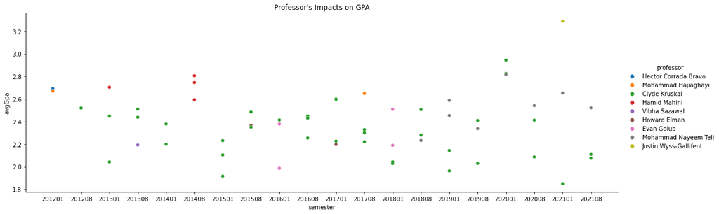

```python
import matplotlib.pyplot as plt
#from matplotlib import rcParams
import seaborn as sns

sns.relplot(data=cmsc351, x='semester', y='avgGpa', hue='professor', aspect = 3)
plt.title("Professor's Impacts on GPA")
plt.show()
```

**Average GPA vs. Semester for all CMNS classes**

Here we wanted to start graphing our gpa data over time to see if there is a decrease in GPAs in the later 3 semesters (when covid is present). We thought that the scatter plot below was pretty hard to read with all the data points so we made a violin plot. From the violin plot, we can see a pretty drastic decrease in the minimum for the 3 plots, starting in the Spring of 2020 (first semster that covid was very present). This is something that we were not able to see claerly with the previous graph.

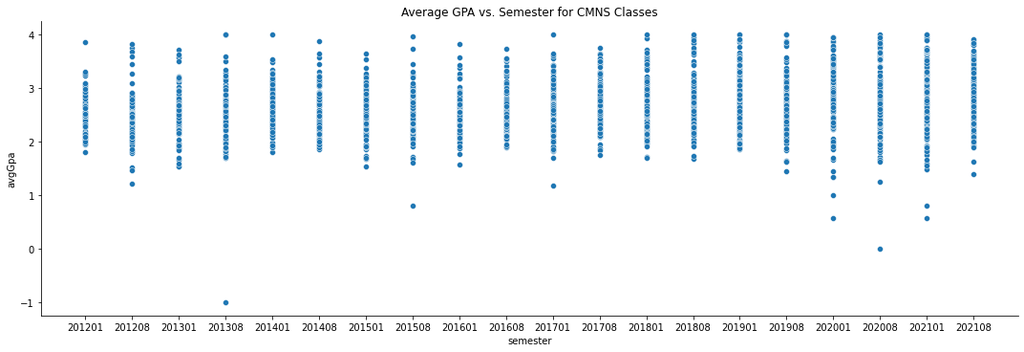

```python
sns.relplot(data=allCmsc, x='semester', y='avgGpa', aspect = 3)
plt.title("Average GPA vs. Semester for CMNS Classes")
plt.show()
```

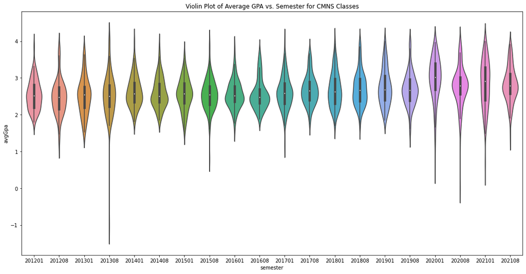

```python
fig, ax = plt.subplots(figsize=(18,9))

sns.violinplot(x = 'semester', y = 'avgGpa', data = allCmsc, ax = ax)
plt.title("Violin Plot of Average GPA vs. Semester for CMNS Classes")
plt.show()
```

```python
# returns a dataframe of the average gpas of all the classes in df parameter over 4 different time frames
# also updates parameter df to contain a column indicating what timeframe it is in
# timeframe is with covid (full online learning) and passfail (202001/202101), covid no passfail (202108), pre-covid, and
# blended learning post-covid (202108)
def splitByTimeframe(df, dept):

  gpas = [[0 for i in range(4)] for j in range(5)]
  numClasses = [[0 for i in range(4)] for j in range(5)]
  #numPF = [0,0,0,0]
  levels = [[],[],[],[],[]]
  timeframes = []

  for index, row in df.iterrows():

      levelIdx = -1

      # checks to see what level current course is
      if (dept + '1') in row['course']:
        levelIdx = 0

      elif (dept + '2') in row['course']:
        levelIdx = 1

      elif (dept + '3') in row['course']:
        levelIdx = 2

      # level 400
      else:
        levelIdx = 3

      i = 3

      # covid
      if row['semester'] == '202001' or row['semester'] == '202101':
        i = 0
        timeframes.append('Online w/PF')

      # covid no passfail
      elif row['semester'] == '202008':
        i = 1
        timeframes.append('Online w/oPF')

      elif row['semester'] == '202108':
        i = 2
        timeframes.append('Post-Covid')

      else:
        timeframes.append('In-Person')

      gpas[levelIdx][i] += row['avgGpa']
      numClasses[levelIdx][i]+= 1

      # updates total gpa
      gpas[4][i] += row['avgGpa']
      numClasses[4][i]+= 1

  for i in range(0,5) :
    for j in range(0,4):
      gpas[i][j] = gpas[i][j] / numClasses[i][j]

  byEra = pd.DataFrame()

  byEra['timeframe'] = ['Online w/PF', 'Online w/oPF', 'Post-Covid', 'In-Person']
  byEra['1xxAvgGpa'] = gpas[0]
  byEra['2xxAvgGpa'] = gpas[1]
  byEra['3xxAvgGpa'] = gpas[2]
  byEra['4xxAvgGpa'] = gpas[3]
  byEra['Overall'] = gpas[4]

  #creates a new column in original dataframe to determine which timeframe a course was in
  df['timeframe'] = timeframes

  return byEra

cmscSplit = splitByTimeframe(allCmsc, 'CMSC')
cmscSplit
```

|  | timeframe | 1xxAvgGpa | 2xxAvgGpa | 3xxAvgGpa | 4xxAvgGpa | Overall |
| --- | --- | --- | --- | --- | --- | --- |
| 0 | Online w/PF | 2.688251 | 2.577258 | 3.223005 | 3.235962 | 2.898450 |
| 1 | Online w/oPF | 2.639761 | 2.601943 | 3.124569 | 2.852766 | 2.777223 |
| 2 | Post-Covid | 2.746054 | 2.610656 | 3.088921 | 2.965528 | 2.831868 |
| 3 | In-Person | 2.449223 | 2.498149 | 2.799069 | 2.862944 | 2.622081 |

**Violin plot of CMNS data in the 4 time frames**

From the plot below we can see that adding this extra variable of the pass/fail option, greatly impacted our data. When pass fail is not used the average of the GPAs drops.

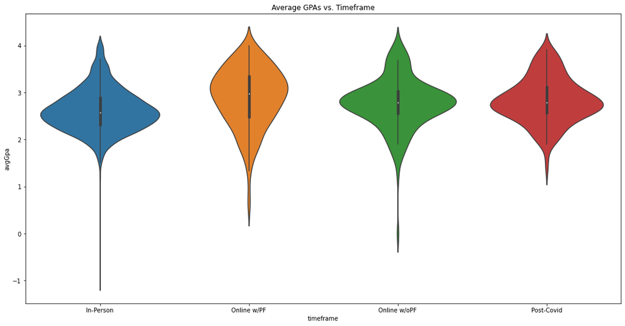

```python
fig, ax = plt.subplots(figsize=(18,9))
sns.violinplot(x = 'timeframe', y = 'avgGpa', data = allCmsc, ax = ax)
plt.title("Average GPAs vs. Timeframe")
plt.show()
```

**Graphs for GPAs by Department for Given TimeFrames**

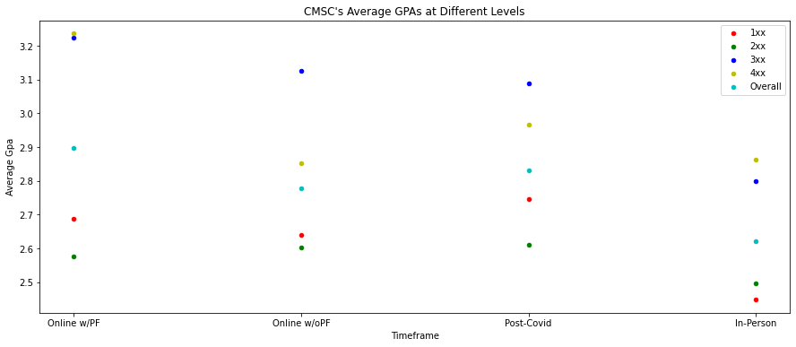

```python
def plotAllTimeframes(df, dept):
  ax1 = df.plot(kind='scatter', x='timeframe', y='1xxAvgGpa', color='r',label = '1xx', figsize = (15,6))
  df.plot(kind='scatter', x='timeframe', y='2xxAvgGpa', color='g', label = '2xx', ax=ax1)
  df.plot(kind='scatter', x='timeframe', y='3xxAvgGpa', color='b', label = '3xx', ax=ax1)
  df.plot(kind='scatter', x='timeframe', y='4xxAvgGpa', color='y', label = '4xx', ax=ax1)
  df.plot(kind='scatter', x='timeframe', y='Overall', color='c', label = 'Overall', ax=ax1)

  plt.title(dept + '\'s Average GPAs at Different Levels')
  plt.xlabel('Timeframe')
  plt.ylabel('Average Gpa')

  plt.show()

plotAllTimeframes(cmscSplit, 'CMSC')
```

```python
allMath = getAllInDept('MATH')
```

```python
mathSplit = splitByTimeframe(allMath, 'MATH')
mathSplit
```

|  | timeframe | 1xxAvgGpa | 2xxAvgGpa | 3xxAvgGpa | 4xxAvgGpa | Overall |
| --- | --- | --- | --- | --- | --- | --- |
| 0 | Online w/PF | 2.720450 | 3.214104 | 2.984257 | 3.019131 | 2.933276 |
| 1 | Online w/oPF | 2.796958 | 2.851728 | 2.585803 | 2.821690 | 2.811064 |
| 2 | Post-Covid | 2.467331 | 2.750201 | 2.913384 | 2.815693 | 2.603999 |
| 3 | In-Person | 2.291674 | 2.551983 | 2.760859 | 2.579174 | 2.438245 |

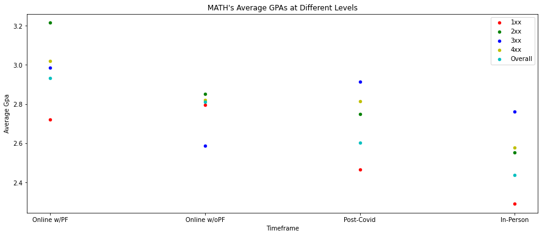

```python
plotAllTimeframes(mathSplit, 'MATH')
```

```python
allMusc = getAllInDept('MUSC')
muscSplit = splitByTimeframe(allMusc, 'MUSC')
muscSplit
```

|  | timeframe | 1xxAvgGpa | 2xxAvgGpa | 3xxAvgGpa | 4xxAvgGpa | Overall |
| --- | --- | --- | --- | --- | --- | --- |
| 0 | Online w/PF | 3.639132 | 3.750663 | 3.811968 | 3.770518 | 3.728616 |
| 1 | Online w/oPF | 3.600237 | 3.633664 | 3.667397 | 3.800612 | 3.643865 |
| 2 | Post-Covid | 3.449384 | 3.500364 | 3.662591 | 3.636064 | 3.518958 |
| 3 | In-Person | 3.402110 | 3.309034 | 3.600116 | 3.611213 | 3.395414 |

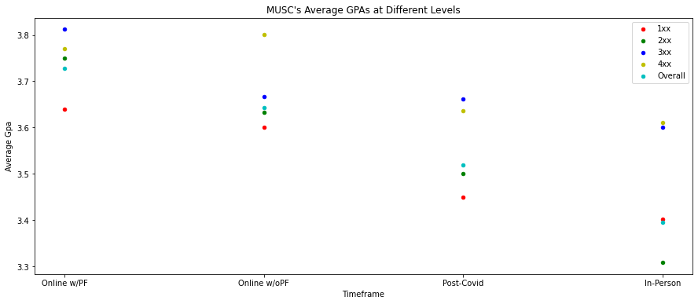

```python
plotAllTimeframes(muscSplit, 'MUSC')
```

```python
allBmgt = getAllInDept('BMGT')
bmgtSplit = splitByTimeframe(allBmgt, 'BMGT')
bmgtSplit
```

|  | timeframe | 1xxAvgGpa | 2xxAvgGpa | 3xxAvgGpa | 4xxAvgGpa | Overall |
| --- | --- | --- | --- | --- | --- | --- |
| 0 | Online w/PF | 3.765234 | 3.283584 | 3.608058 | 3.523604 | 3.521290 |
| 1 | Online w/oPF | 3.492366 | 2.913467 | 3.318310 | 3.519916 | 3.302857 |
| 2 | Post-Covid | 3.563029 | 2.856369 | 3.267774 | 3.399433 | 3.248695 |
| 3 | In-Person | 3.311203 | 2.678534 | 3.218807 | 3.414313 | 3.194959 |

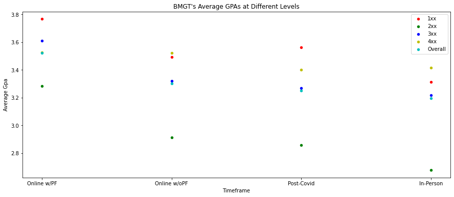

```python
plotAllTimeframes(bmgtSplit, 'BMGT')
```

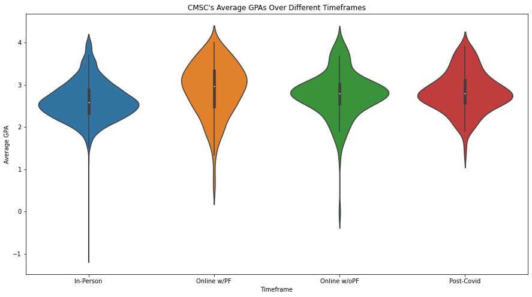

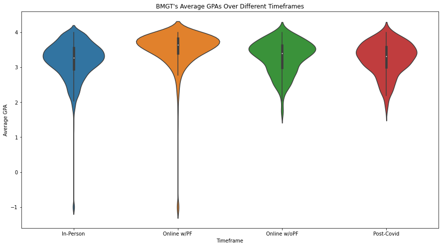

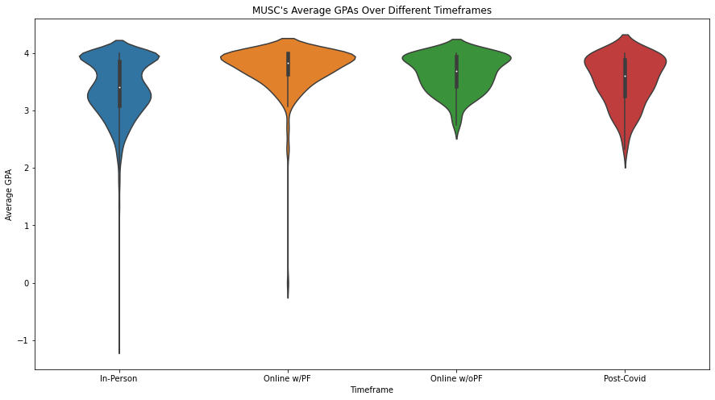

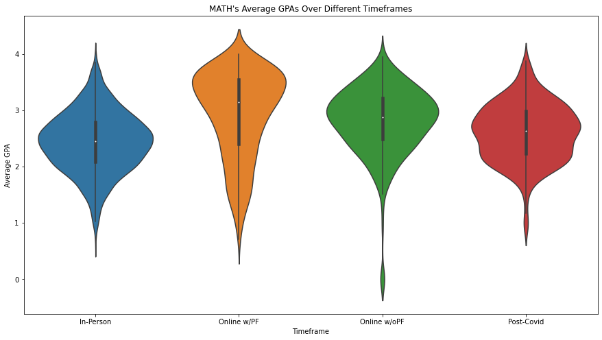

```python
frames = [allCmsc, allBmgt, allMusc, allMath]
depts = ['CMSC', 'BMGT', 'MUSC', 'MATH']

# creates violin plots for all 4 departments
for i in range(0,4):
  fig, ax = plt.subplots(figsize=(15, 8))

  sns.violinplot(x = 'timeframe', y = 'avgGpa', data = frames[i], ax = ax)

  plt.xlabel('Timeframe')
  plt.ylabel('Average GPA')

  plt.title(depts[i] + '\'s Average GPAs Over Different Timeframes')
  plt.show()
```

**4. Hypothesis testing**

Upon diving into our various datasets, we have been able to see how the COVID-19 pandemic has affected academics.

As we mentioned earlier, before starting the project we believed that the grades for the harder department will drop more because the department is already challenging.

Therefore, our **null hypothesis** in this project is that student’s grades in the hardest departments were NOT affected more than the other departments due to the COVID-19 pandemic.

Our **alternative hypothesis** is that student’s grades in the hardest department are affected the most from COVID out of the 4 departments we looked at.

We further believe that grades in the hardest department worsened the most at the start of the pandemic, but as students got more and more adjusted to various types of learning (such as online and blended), their grades would get slightly better. Now that classes are back in-person for the most part, we suspect that grades are doing much better than they were at the start of COVID-19.

**5.Insight**

We discovered that

The Math department had the lowest GPA before COVID, and upon switching to online learning, the median of GPAs increased drastically and overtime it they are going back to normal. This can definitely be attributed to the addition of a Pass/Fail option, as the massive jump in average GPA happened right at that time.

The CS department, similar to the Math department, saw a pretty sharp increase in GPA when Pass/Fail was introduced as a result of COVID. Overtime, however, the GPAs started to fall back to normal.

Therefore, we can conclude that although some departments are harder to teach online, the addition of a Pass/Fail option and other exceptions being made during the pandemic may have aided students and boosted their GPAs.

We can only speculate that with online learning there was an uptick in cheating, which is why many professors made their exams harder but open-note.

It is well-known that many people have been suffering with anxiety and other mental illnesses as a result of the pandemic. This may have had very negative impacts on students as well, however the approach that these departments took helped aid their students to do better as opposed to fail.

```python
%%shell
jupyter nbconvert --to html /content/finalproject.ipynb
```

```
[NbConvertApp] Converting notebook /content/finalproject.ipynb to html
[NbConvertApp] Writing 992314 bytes to /content/finalproject.html
```